# M505DAssignment

*Problem Statement*

The organization that I am working on has an objective of emoloying digital campaigns to influence their clients. The company therefore intends to predict the chances/probability of a client to convert,and this is where I an a data analyst comes in.

*Business Problem*

The company experiences a challenge in efficiently allocating marketing budget and resources due to inconsistent customer conversions from digital campaigns. Main business problem; to predict the likelihood of a customer converting after interacting with digital marketing efforts. This prediction is vital for optimizing marketing strategies, increasing ROI, and improving customer targeting.

*Importance of Solving the Problem:*

By accurately predicting customer conversions, the company can stay competitive in the digital marketing landscape, improve profitability by channeling limited resources appropriately, and fostering stronger customer relationships.

*Data Collection:*

The company provided dataset, which includes key features needed for predictive modeling, such as demographic data (e.g., Age, Gender), marketing interaction data (e.g., CampaignChannel, AdSpend), and engagement metrics (e.g., ClickThroughRate, WebsiteVisits). The dataset is sufficient for me to predict the probability of a client converting.

Here is the link to the dataset from the public source Kaggle:

https://www.kaggle.com/datasets/rabieelkharoua/predict-conversion-in-digital-marketing-dataset

*Formulating as a Machine Learning Task:*

The problem of predicting conversions can be formulated as a *supervised machine learning classification task*. The target variable is binary (1 for conversion, 0 for no conversion). The goal is to train a model using labeled data to accurately classify customers into "convert" or "not convert" categories based on their features. The project involves:

Identifying predictive features i.e features that influence client decision.

Preprocessing the data to ensure quality e.g handling missing values, encoding categorical variables etc

Training and evaluating different machine learning models such as logistic regression, random forests, or Knn to optimize prediction performance.

Importing the relevant Libraries

```python
import pandas as pd
import numpy as np
import sklearn.model_selection
import sklearn.tree
import sklearn.metrics
from sklearn.tree import DecisionTreeClassifier
import matplotlib.pyplot as plt
from sklearn.preprocessing import StandardScaler
from sklearn.tree import plot_tree
from sklearn.preprocessing import OneHotEncoder
from sklearn.neighbors import KNeighborsClassifier
from sklearn.model_selection import GridSearchCV
from sklearn.model_selection import RandomizedSearchCV
from sklearn.ensemble import RandomForestClassifier
```

Loading the data

```python
data = pd.read_csv('/content/digital_marketing_campaign_dataset.csv.zip')
print('The shape of the data is: ', data.shape)
data.head(4)
```

```
The shape of the data is:  (8000, 20)
```

|  | CustomerID | Age | Gender | Income | CampaignChannel | CampaignType | AdSpend | ClickThroughRate | ConversionRate | WebsiteVisits | PagesPerVisit | TimeOnSite | SocialShares | EmailOpens | EmailClicks | PreviousPurchases | LoyaltyPoints | AdvertisingPlatform | AdvertisingTool | Conversion |
| --- | --- | --- | --- | --- | --- | --- | --- | --- | --- | --- | --- | --- | --- | --- | --- | --- | --- | --- | --- | --- |
| 0 | 8000 | 56 | Female | 136912 | Social Media | Awareness | 6497.870068 | 0.043919 | 0.088031 | 0 | 2.399017 | 7.396803 | 19 | 6 | 9 | 4 | 688 | IsConfid | ToolConfid | 1 |
| 1 | 8001 | 69 | Male | 41760 | Email | Retention | 3898.668606 | 0.155725 | 0.182725 | 42 | 2.917138 | 5.352549 | 5 | 2 | 7 | 2 | 3459 | IsConfid | ToolConfid | 1 |
| 2 | 8002 | 46 | Female | 88456 | PPC | Awareness | 1546.429596 | 0.277490 | 0.076423 | 2 | 8.223619 | 13.794901 | 0 | 11 | 2 | 8 | 2337 | IsConfid | ToolConfid | 1 |
| 3 | 8003 | 32 | Female | 44085 | PPC | Conversion | 539.525936 | 0.137611 | 0.088004 | 47 | 4.540939 | 14.688363 | 89 | 2 | 2 | 0 | 2463 | IsConfid | ToolConfid | 1 |

```python
#Checking if the data is clean- The data is clean.
data.isna().sum()
```

|  | 0 |
| --- | --- |
| CustomerID | 0 |
| Age | 0 |
| Gender | 0 |
| Income | 0 |
| CampaignChannel | 0 |
| CampaignType | 0 |
| AdSpend | 0 |
| ClickThroughRate | 0 |
| ConversionRate | 0 |
| WebsiteVisits | 0 |
| PagesPerVisit | 0 |
| TimeOnSite | 0 |
| SocialShares | 0 |
| EmailOpens | 0 |
| EmailClicks | 0 |
| PreviousPurchases | 0 |
| LoyaltyPoints | 0 |
| AdvertisingPlatform | 0 |
| AdvertisingTool | 0 |
| Conversion | 0 |

**dtype:** int64

```python
# data.dtypes - All the data was correct i.e no numerical data that was classified as 'object'
data.describe().T
```

|  | count | mean | std | min | 25% | 50% | 75% | max |
| --- | --- | --- | --- | --- | --- | --- | --- | --- |
| CustomerID | 8000.0 | 11999.500000 | 2309.545410 | 8000.000000 | 9999.750000 | 11999.500000 | 13999.250000 | 15999.000000 |
| Age | 8000.0 | 43.625500 | 14.902785 | 18.000000 | 31.000000 | 43.000000 | 56.000000 | 69.000000 |
| Income | 8000.0 | 84664.196750 | 37580.387945 | 20014.000000 | 51744.500000 | 84926.500000 | 116815.750000 | 149986.000000 |
| AdSpend | 8000.0 | 5000.944830 | 2838.038153 | 100.054813 | 2523.221165 | 5013.440044 | 7407.989369 | 9997.914781 |
| ClickThroughRate | 8000.0 | 0.154829 | 0.084007 | 0.010005 | 0.082635 | 0.154505 | 0.228207 | 0.299968 |
| ConversionRate | 8000.0 | 0.104389 | 0.054878 | 0.010018 | 0.056410 | 0.104046 | 0.152077 | 0.199995 |
| WebsiteVisits | 8000.0 | 24.751625 | 14.312269 | 0.000000 | 13.000000 | 25.000000 | 37.000000 | 49.000000 |
| PagesPerVisit | 8000.0 | 5.549299 | 2.607358 | 1.000428 | 3.302479 | 5.534257 | 7.835756 | 9.999055 |
| TimeOnSite | 8000.0 | 7.727718 | 4.228218 | 0.501669 | 4.068340 | 7.682956 | 11.481468 | 14.995311 |
| SocialShares | 8000.0 | 49.799750 | 28.901165 | 0.000000 | 25.000000 | 50.000000 | 75.000000 | 99.000000 |
| EmailOpens | 8000.0 | 9.476875 | 5.711111 | 0.000000 | 5.000000 | 9.000000 | 14.000000 | 19.000000 |
| EmailClicks | 8000.0 | 4.467375 | 2.856564 | 0.000000 | 2.000000 | 4.000000 | 7.000000 | 9.000000 |
| PreviousPurchases | 8000.0 | 4.485500 | 2.888093 | 0.000000 | 2.000000 | 4.000000 | 7.000000 | 9.000000 |
| LoyaltyPoints | 8000.0 | 2490.268500 | 1429.527162 | 0.000000 | 1254.750000 | 2497.000000 | 3702.250000 | 4999.000000 |
| Conversion | 8000.0 | 0.876500 | 0.329031 | 0.000000 | 1.000000 | 1.000000 | 1.000000 | 1.000000 |

```python
#Showing differences in a feature e.g how many gender...
data.nunique()
```

|  | 0 |
| --- | --- |
| CustomerID | 8000 |
| Age | 52 |
| Gender | 2 |
| Income | 7789 |
| CampaignChannel | 5 |
| CampaignType | 4 |
| AdSpend | 8000 |
| ClickThroughRate | 8000 |
| ConversionRate | 8000 |
| WebsiteVisits | 50 |
| PagesPerVisit | 8000 |
| TimeOnSite | 8000 |
| SocialShares | 100 |
| EmailOpens | 20 |
| EmailClicks | 10 |
| PreviousPurchases | 10 |
| LoyaltyPoints | 3983 |
| AdvertisingPlatform | 1 |
| AdvertisingTool | 1 |
| Conversion | 2 |

**dtype:** int64

Checking if the data is balanced or imbalanced.

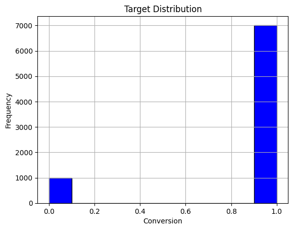

```python
#Balanced or imbalanced data?
data['Conversion'].hist(bins=10, color='blue', edgecolor='black')
plt.xlabel('Conversion')
plt.ylabel('Frequency')
plt.title('Target Distribution')
plt.show()
```

The data (Target) is imbalanced. However, we are going to make use of techniques that work well with unbalanced dataset.

```python
#Splitting Features//targt
X = data.drop(['CustomerID', 'AdvertisingPlatform', 'AdvertisingTool', 'Conversion'], axis = 1)
y = data['Conversion']

#this is the splitting section for train and test.
X_train, X_test, y_train, y_test = sklearn.model_selection.train_test_split(X, y, random_state= 42, test_size= 0.2)

print("shape of X_train: ", X_train.shape)
print("shape of X_test: ", X_test.shape)
print("shape of y_train: ", y_train.shape)
print("shape of y_test: ", y_test.shape)
```

```
shape of X_train:  (6400, 16)
shape of X_test:  (1600, 16)
shape of y_train:  (6400,)
shape of y_test:  (1600,)
```

I dropped customerID column as it is irrelevant to the task. Machine learning models rely on differences in data to make predictions. I therefore dropped AdvertisingPlatform and AdvertisingTool since they contain only 1 unique value.

I then displayed X_test,X_train, y_test, y_train shapes.*

```python
X_train.dtypes
```

|  | 0 |
| --- | --- |
| Age | int64 |
| Gender | object |
| Income | int64 |
| CampaignChannel | object |
| CampaignType | object |
| AdSpend | float64 |
| ClickThroughRate | float64 |
| ConversionRate | float64 |
| WebsiteVisits | int64 |
| PagesPerVisit | float64 |
| TimeOnSite | float64 |
| SocialShares | int64 |
| EmailOpens | int64 |
| EmailClicks | int64 |
| PreviousPurchases | int64 |
| LoyaltyPoints | int64 |

**dtype:** object

```python
X_train_cat = X_train.select_dtypes(include=['object']).columns

# One-Hot-Encoding (training data)
encoder = OneHotEncoder(drop='first', sparse_output=False, handle_unknown='ignore')
X_train_encoded = encoder.fit_transform(X_train[X_train_cat])
X_test_encoded = encoder.transform(X_test[X_train_cat])

X_train_encoded = pd.DataFrame(X_train_encoded, columns=encoder.get_feature_names_out(X_train_cat))
X_test_encoded = pd.DataFrame(X_test_encoded, columns=encoder.get_feature_names_out(X_train_cat))

# Aligning the rows properly
X_train_encoded.index = X_train.index
X_test_encoded.index = X_test.index

# Drop original cat_columns
X_train = X_train.drop(columns=X_train_cat)
X_test = X_test.drop(columns=X_train_cat)

# Merge numerical and encoded categorical data
X_train = pd.concat([X_train, X_train_encoded], axis=1)
X_test = pd.concat([X_test, X_test_encoded], axis=1)
```

The code below separates categorical and numerical data

```python
#Separating categorical and numeri al featurees
categorical_features = X_train.select_dtypes(include=['object']).columns
numerical_features = X_train.select_dtypes(include=['int64', 'float64']).columns
X_train_num = X_train[numerical_features]
X_train_cat = X_train[categorical_features]
X_test_num = X_test[numerical_features]
X_test_cat = X_test[categorical_features]
```

*The blocks of code below shows the attempts of 3 different learning models; KNN, Decision trees and Random forest. The three models work very well with classificaton tasks in supervised machine learning.

I employed *VALIDATIONN SCORE* to determine the best model for my prediction task*

```python
knn = KNeighborsClassifier()

param_grid = {
    "n_neighbors":[3, 5, 7, 9, 11],
    "weights": ['uniform', 'distance'],
    "metric": ['euclidean', 'manhattan'],
    # n_jobs=None)

}

grid_knn = GridSearchCV(knn, param_grid, cv = 5, scoring = "accuracy", error_score='raise')
grid_knn.fit(X_train, y_train)

opt_params = grid_knn.best_params_
print('Optimal parameters for Knn: ', opt_params)
print("The best score for grid search is: ", grid_knn.best_score_)
```

```
Optimal parameters for Knn:  {'metric': 'euclidean', 'n_neighbors': 11, 'weights': 'uniform'}
The best score for grid search is:  0.87578125
```

Finding the best score for Decision Tree

```python
#Decision Tree
dct = DecisionTreeClassifier()

param_grid = {

    "criterion": ["gini", "entropy"],
    "splitter": ["best", "random"],
    "max_depth": [5, 10, 20],
    "min_samples_split": [2, 5, 10],
    "min_samples_leaf": [1, 2, 5, 10],

    "max_features": ["sqrt", "log2"],
    "max_leaf_nodes": [10, 20, 50],

    "class_weight": ["balanced"],

}


grid_dt = GridSearchCV(dct, param_grid, cv = 5, scoring = "accuracy", n_jobs= -1)
grid_dt.fit(X_train, y_train)

opt_params = grid_dt.best_params_
print('Optimal parameters for dct: ', opt_params)

print("The bes score for grid search is: ", grid_dt.best_score_) #  Validation Score
```

```
Optimal parameters for dct:  {'class_weight': 'balanced', 'criterion': 'entropy', 'max_depth': 20, 'max_features': 'log2', 'max_leaf_nodes': 10, 'min_samples_leaf': 5, 'min_samples_split': 2, 'splitter': 'best'}
The bes score for grid search is:  0.7753124999999998
```

Finding the best score for random forest

```python
# Define the model
rf = RandomForestClassifier()

# Define the hyperparameter grid
param_grid = {
    "n_estimators": [50, 100, 200],
    "criterion": ["gini", "entropy"],
    "max_depth": [10, 20],
    "min_samples_split": [2, 5, 10],
    "min_samples_leaf": [1, 2, 5],
    "max_features": ["sqrt", "log2"],
    "bootstrap": [True, False],
    "n_jobs": [-1]
}

# Perform Grid Search with 5-fold cross-validation
grid_rf = GridSearchCV(rf, param_grid, cv=5, scoring="accuracy", n_jobs=-1)
grid_rf.fit(X_train, y_train)

# Get the best parameters
opt_params = grid_rf.best_params_
print("Optimal parameters for RandomForestClassifier:", opt_params)
print("The bes score for grid search is: ", grid_rf.best_score_)
```

```
Optimal parameters for RandomForestClassifier: {'bootstrap': False, 'criterion': 'entropy', 'max_depth': 20, 'max_features': 'log2', 'min_samples_leaf': 1, 'min_samples_split': 2, 'n_estimators': 50, 'n_jobs': -1}
The bes score for grid search is:  0.90265625
```

I now proceed to making predictions on my test set.

```python
from sklearn.metrics import accuracy_score, precision_score, recall_score, f1_score, confusion_matrix

# Make predictions on the test set
y_pred = grid_rf.predict(X_test)

# Evaluate performance using multiple metrics
accuracy = accuracy_score(y_test, y_pred)
precision = precision_score(y_test, y_pred, average='weighted')
recall = recall_score(y_test, y_pred, average='weighted')
f1 = f1_score(y_test, y_pred, average='weighted')

# Print metrics

print("Precision:", precision)
print("Recall:", recall)
print("F1 Score:", f1)
```

```
Precision: 0.8896170737114985
Recall: 0.899375
F1 Score: 0.8742509345459801
```

A precison score of .89 is fairly good. The model correctly predicts 89 percent of positives as positives i.e positives are not often classifies as negatives.

F1 Score balances precision and recall. The F1 score of 0.87 is nearing 1, showing that the model has a good tradeoff between identifying true positives and avoiding false positives.

**OVERALL STRENGTHS AND WEKNESSES**

**Strengths**

1. The pipeline is Robust. By applying hyperparameter tuning with GridSearchCSV, optimal configuration are used for all models.

The pipeline also evaluates KNN, Decision trees and Random Forest. The compariosn allowed me to select the best model.

*** Weaknesses***

1. Random forest may have overfitting, especially if a large number of dataset is involved.
2. Even with weighted metrics, imbalanced data may lead to skewed predictions favoring dominant classes. I could consider techniques like SMOTE (Synthetic Minority Oversampling Technique) to balance the training data further.

**IMPLICATIONS TO THE BUSINESS**

1. By predicting the likelihood of a customer converting, the company can efficiently allocate marketing budgets and resources. For instance, more focus can be placed on high-probability customers, reducing wasteful spending on low-probability customers.
2. The model enables personalized customer targeting. Marketing campaigns can be tailored to customers with a high conversion probability, enhancing the overall effectiveness of digital campaigns and increasing the chances of engagement.
3. This predictive model empowers the organization to make informed, data-driven decisions, replacing guesswork with actionable insights. Therefore, marketing strategies will be backed by data and statistics.

**Explainability**

The model is parially explaimable as plots and graphs can be added if necessary for every data decision made. For instance, the confusion matrix can be displayed for better explanation.